# Workshop: La Inteligencia Artificial aplicada al mundo real , 2019

Sergio Villordo

## 1 - Intall Python and required packages

Suggested alternative: install Conda, create an environment with python and then run the example notebook using jupyter lab.

Quick install and some tips at Linux:

1) download miniconda installer:

> wget https://repo.continuum.io/miniconda/Miniconda3-latest-Linux-x86_64.sh

2) install

> bash Miniconda3-latest-Linux-x86_64.sh

3) Install supports for jupyter lab (more details at "https://github.com/jupyterlab/jupyterlab")

> conda install -c conda-forge jupyterlab

4) create an environment (default Python 3.6.5)

> conda create --name py36

5) open the environment and required packages

> source activate py36

> conda install -c numpy scipy matplotlib pandas scikit-learn ipython nbconvert tensorflow keras nb_conda opencv

> conda install nb_conda 6) Finally, open jupyter lab and run the notebook(.ipynb)

For more informations using install using another OS "https://conda.io/docs/user-guide/install/index.html"

http://alexlenail.me/NN-SVG/LeNet.html

### Used Frameworks

[figure not shown]

## 2 - RUNNING

```python
import os
import glob
import cv2
import datetime
import pandas as pd
import numpy as np
import time
import warnings
warnings.filterwarnings("ignore")
import scipy

np.random.seed(12345)
from sklearn.model_selection import KFold
from keras.models import Sequential
from keras.layers.core import Dense, Dropout, Flatten, Activation,Lambda
from keras.layers.convolutional import Convolution2D,Conv2D, MaxPooling2D, ZeroPadding2D,AveragePooling2D
from keras.optimizers import SGD
from keras.callbacks import EarlyStopping
from keras.utils import np_utils
from sklearn.metrics import accuracy_score, log_loss
from keras import __version__ as keras_version

import matplotlib.pyplot as plt
%matplotlib inline
```

```python
def getImaArrays(folder):
    X = []
    y = []
    y_name=[]
    y_filename =[]
    for subfolder in os.listdir(folder):
        index = os.listdir(folder).index(subfolder)
        for image_filename in os.listdir(folder + subfolder):
                img_file = cv2.imread(folder + subfolder + '/' + image_filename , 0)
                if img_file is not None:
                    flbase = os.path.basename(folder + subfolder + '/' + image_filename)
                    X.append(img_file)
                    y.append(index)
                    y_name.append(subfolder)
                    y_filename.append(flbase)

    y = np.array(y, dtype=np.uint8)
    X = np.array(X, dtype=np.uint8)
    X = X.astype('float32')
    y_filename= np.array(y_filename,dtype=object)
    y_name= np.array(y_name,dtype=object)
    return X,y,y_filename, y_name
```

### Quick Draw Project - Image Source

https://quickdraw.withgoogle.com/

[figure not shown]

# Generated Dataset

[figure not shown]

### Reading images and putting into arrays

```python
X_train, y_train, y_train_file, y_train_name = getImaArrays( 'datasets/images/' + 'train/')
X_train= X_train / 255

X_test, y_test, y_test_file, y_test_name = getImaArrays( 'datasets/images/' + 'test/')
X_test= X_test / 255
```

### Randomization of datasets

```python
np.random.seed(12345)
permutation = np.random.permutation(X_train.shape[0])
X_train = X_train[permutation, :]
y_train = y_train[permutation]
y_train_file = y_train_file[permutation]
y_train_name = y_train_name[permutation]


np.random.seed(12345)
permutation = np.random.permutation(X_test.shape[0])
X_test = X_test[permutation, :]
y_test = y_test[permutation]
y_test_file = y_test_file[permutation]
y_test_name = y_test_name[permutation]
```

```python
np.unique(y_test_name.astype(str))
```

```
array(['apple', 'banana', 'blackberry', 'blueberry', 'grapes', 'peanut',
       'pear', 'strawberry'], dtype='<U10')
```

```python
# Transform categories to dummy
y_train = np_utils.to_categorical(y_train, 8)
y_test = np_utils.to_categorical(y_test, 8)
```

# Option 1 - Simple Linear Model

```python
#Settings
epochs= 15
batch_size=128
```

Notes:

- usue of "[softmax](https://en.wikipedia.org/wiki/Softmax_function)" activation function
- The batch size defines the number of samples that will be propagated through the network.

```python
# X_train = X_train.reshape(X_train.shape[0], 784)
# X_train.shape
# X_test = X_test.reshape(X_test.shape[0], 784)
# X_test.shape
```

```python
model= Sequential()
model.add(Lambda(lambda x: x, input_shape=(28, 28)))
model.add(Flatten())
model.add(Dense(8, activation='softmax' ))
```

[output not shown]

```python
print(model.summary())
```

```
_________________________________________________________________
Layer (type)                 Output Shape              Param #
=================================================================
lambda_1 (Lambda)            (None, 28, 28)            0
_________________________________________________________________
flatten_1 (Flatten)          (None, 784)               0
_________________________________________________________________
dense_1 (Dense)              (None, 8)                 6280
=================================================================
Total params: 6,280
Trainable params: 6,280
Non-trainable params: 0
_________________________________________________________________
None
```

```python
from IPython.display import SVG
from keras.utils.vis_utils import model_to_dot

def plot_keras_model(model, show_shapes=True,show_layer_names=True):
    return SVG(model_to_dot(model, show_shapes=show_shapes,show_layer_names=show_layer_names).create(prog='dot',format='svg'))
```

```python
plot_keras_model(model, show_shapes=True, show_layer_names=False)
```

[figure not shown]

### Schematic View

[figure not shown]

```python
model.compile(optimizer='Adadelta',
             loss='categorical_crossentropy',
             metrics=['accuracy'])
```

```python
# fits the model on batches
history = model.fit(
            X_train,
            y_train,
            validation_split=0.2,
            epochs=epochs,
            shuffle=False,
            batch_size=batch_size,
            verbose=0)
```

[output not shown]

```python
history_dict = history.history
history_dict.keys()
```

```
dict_keys(['val_loss', 'val_acc', 'loss', 'acc'])
```

```python
def plot_learning_curve(history):
    fig = plt.figure(figsize=(6, 6), dpi= 80, facecolor='w', edgecolor='k')
    plt.subplot(2,1,1)
    plt.plot(history.history['acc'])
    plt.plot(history.history['val_acc'])
    plt.title('model accuracy')
    plt.ylabel('accuracy')
    plt.xlabel('epoch')
    plt.legend(['train', 'test'], loc='center right')

    plt.subplot(2,1,2)
    plt.plot(history.history['loss'])
    plt.plot(history.history['val_loss'])
    plt.title('model loss')
    plt.ylabel('loss')
    plt.xlabel('epoch')
    plt.legend(['train', 'test'], loc='center right')
    plt.tight_layout()
```

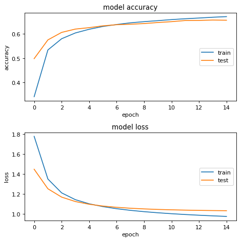

```python
plot_learning_curve(history)
```

```python
predictions_valid = model.predict(X_test.astype('float32'), batch_size=batch_size, verbose=2)
score_acc = accuracy_score(y_test, predictions_valid.round())
score_acc
#score_logloss = log_loss(y_test, predictions_valid.round())
#score_logloss
```

```
0.548125
```

# Option 2 - Multi Layer Perceptron (MLP)

```python
#Settings
epochs= 15
batch_size=128
```

```python
model= Sequential()
model.add(Lambda(lambda x: x, input_shape=(28, 28)))
model.add(Flatten())
model.add(Dense(128, activation='tanh' ))
model.add(Dense(8, activation='softmax' ))
```

```python
print(model.summary())
```

```
_________________________________________________________________
Layer (type)                 Output Shape              Param #
=================================================================
lambda_2 (Lambda)            (None, 28, 28)            0
_________________________________________________________________
flatten_2 (Flatten)          (None, 784)               0
_________________________________________________________________
dense_2 (Dense)              (None, 128)               100480
_________________________________________________________________
dense_3 (Dense)              (None, 8)                 1032
=================================================================
Total params: 101,512
Trainable params: 101,512
Non-trainable params: 0
_________________________________________________________________
None
```

```python
plot_keras_model(model, show_shapes=True, show_layer_names=False)
```

[figure not shown]

### Schematic View

[figure not shown]

```python
model.compile(optimizer='Adadelta',
             loss='categorical_crossentropy',
             metrics=['accuracy'])
```

```python
# fits the model on batches
history = model.fit(
            X_train,
            y_train,
            validation_split=0.2,
            epochs=epochs,
            shuffle=False,
            batch_size=batch_size,
            verbose=0)
```

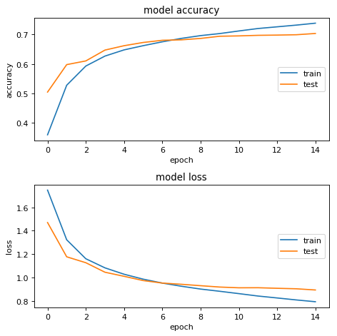

```python
plot_learning_curve(history)
```

```python
predictions_valid = model.predict(X_test.astype('float32'), batch_size=batch_size, verbose=2)
score_acc = accuracy_score(y_test, predictions_valid.round())
score_acc
```

```
0.63
```

### Introducing some changes to improve

- "tanh" -> "relu".
- Introducing "dropout" to control the "[overffiting](https://en.wikipedia.org/wiki/Overfitting)".
- Adding a one more "hidden layer"
- increasing the amount of generations (epochs")

```python
#Settings
epochs = 50
batch_size = 128
```

```python
model= Sequential()
model.add(Lambda(lambda x: x, input_shape=(28, 28)))
model.add(Flatten())
model.add(Dense(516, activation='relu' ))
model.add(Dropout(0.2))
model.add(Dense(128, activation='relu' ))
model.add(Dropout(0.2))
model.add(Dense(8, activation='softmax' ))
```

[output not shown]

```python
print(model.summary())
```

```
_________________________________________________________________
Layer (type)                 Output Shape              Param #
=================================================================
lambda_3 (Lambda)            (None, 28, 28)            0
_________________________________________________________________
flatten_3 (Flatten)          (None, 784)               0
_________________________________________________________________
dense_4 (Dense)              (None, 516)               405060
_________________________________________________________________
dropout_1 (Dropout)          (None, 516)               0
_________________________________________________________________
dense_5 (Dense)              (None, 128)               66176
_________________________________________________________________
dropout_2 (Dropout)          (None, 128)               0
_________________________________________________________________
dense_6 (Dense)              (None, 8)                 1032
=================================================================
Total params: 472,268
Trainable params: 472,268
Non-trainable params: 0
_________________________________________________________________
None
```

```python
plot_keras_model(model, show_shapes=True, show_layer_names=False)
```

[figure not shown]

### Schematic View

[figure not shown]

```python
model.compile(optimizer='Adadelta',
             loss='categorical_crossentropy',
             metrics=['accuracy'])
```

```python
# fits the model on batches
history = model.fit(
            X_train,
            y_train,
            validation_split=0.2,
            epochs=epochs,
            shuffle=False,
            batch_size=batch_size,
            verbose=0)
```

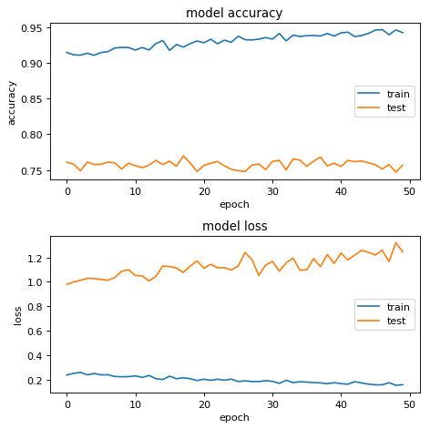

```python
plot_learning_curve(history)
```

```python
predictions_valid = model.predict(X_test.astype('float32'), batch_size=batch_size, verbose=2)
score_acc = accuracy_score(y_test, predictions_valid.round())
score_acc
```

```
0.73625
```

# Option 3 - Convolutional Neural Networks (CNN)

## LENET -5 Architecture

[figure not shown]

Yann LeCun, Leon Bottou, Yosuha Bengio and Patrick Haffner proposed a neural network architecture for handwritten and machine-printed character recognition in 1990’s which they called LeNet-5. he LeNet-5 architecture consists of two sets of convolutional and average pooling layers, followed by a flattening convolutional layer, then two fully-connected layers and finally a softmax classifier. The input plane receives images of characters that are approximately size normalized and centere. Each unit in a layer receives inputs from a set of units located in a small neighborhood (local receptive fields LRF). With local receptive fields neurons can extract elementary visual features such as oriented edges, endpoints, corners. These features are then combined by the subsequent layers in order to detect higher order features.

```python
# Settings
epochs = 15
batch_size = 128
```

```python
#Reshape the training and test set
X_train = X_train.reshape(X_train.shape[0], 28, 28, 1)
X_test = X_test.reshape(X_test.shape[0], 28, 28, 1)
```

```python
model= Sequential()
# First layer:
model.add(Convolution2D(6, kernel_size=(5,5), padding="same", input_shape=(28, 28,1)))
model.add(Activation('tanh'))
# Second hidden layer
model.add(AveragePooling2D(pool_size=(2, 2)))
# Third hidden layer
model.add(Convolution2D(filters = 16,  kernel_size=(5,5), padding="same"))
model.add(Activation('tanh'))
# Fourth hidden layer
model.add(AveragePooling2D(pool_size=(2,2)))
# Flatten output into feature vector and feed into dense layer
model.add(Flatten())
# Here start the MLP with two hidden layers
model.add(Dense(120))
model.add(Activation('tanh'))
model.add(Dense(84 ))
model.add(Activation('tanh'))
model.add(Dense(8 ))
model.add(Activation('softmax'))
```

```python
print(model.summary())
```

```
_________________________________________________________________
Layer (type)                 Output Shape              Param #
=================================================================
conv2d_1 (Conv2D)            (None, 28, 28, 6)         156
_________________________________________________________________
activation_1 (Activation)    (None, 28, 28, 6)         0
_________________________________________________________________
average_pooling2d_1 (Average (None, 14, 14, 6)         0
_________________________________________________________________
conv2d_2 (Conv2D)            (None, 14, 14, 16)        2416
_________________________________________________________________
activation_2 (Activation)    (None, 14, 14, 16)        0
_________________________________________________________________
average_pooling2d_2 (Average (None, 7, 7, 16)          0
_________________________________________________________________
flatten_4 (Flatten)          (None, 784)               0
_________________________________________________________________
dense_7 (Dense)              (None, 120)               94200
_________________________________________________________________
activation_3 (Activation)    (None, 120)               0
_________________________________________________________________
dense_8 (Dense)              (None, 84)                10164
_________________________________________________________________
activation_4 (Activation)    (None, 84)                0
_________________________________________________________________
dense_9 (Dense)              (None, 8)                 680
_________________________________________________________________
activation_5 (Activation)    (None, 8)                 0
=================================================================
Total params: 107,616
Trainable params: 107,616
Non-trainable params: 0
_________________________________________________________________
None
```

```python
plot_keras_model(model, show_shapes=True, show_layer_names=False)
```

[figure not shown]

```python
model.compile(optimizer='Adadelta',
             loss='categorical_crossentropy',
             metrics=['accuracy'])
```

```python
# fits the model on batches
history = model.fit(
            X_train,
            y_train,
            validation_split=0.2,
            epochs=epochs,
            shuffle=False,
            batch_size=batch_size,
            verbose=0)
```

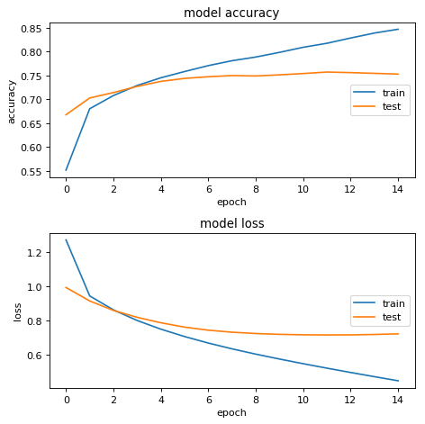

```python
plot_learning_curve(history)
```

```python
predictions_valid = model.predict(X_test.astype('float32'), batch_size=batch_size, verbose=2)
score_acc = accuracy_score(y_test, predictions_valid.round())
score_acc
```

```
0.72125
```

### Introducing some changes to improve

- "tanh" -> "relu".
- increase te amount of generations.
- introducing "dropout" rate.

```python
epochs = 50
```

```python
model= Sequential()
# First layer:
model.add(Convolution2D(6, kernel_size=(5,5), padding="same", input_shape=(28, 28,1)))
model.add(Activation('relu'))
# Second hidden layer
model.add(AveragePooling2D(pool_size=(2, 2)))
# Third hidden layer
model.add(Convolution2D(filters = 16,  kernel_size=(5,5), padding="same"))
model.add(Activation('relu'))
# Fourth hidden layer
model.add(AveragePooling2D(pool_size=(2,2)))
# Flatten output into feature vector and feed into dense layer
model.add(Flatten())
# Here start the MLP with two hidden layers
model.add(Dense(518))
model.add(Activation('relu'))
model.add(Dropout(0.65))
model.add(Dense(128))
model.add(Activation('relu'))
model.add(Dropout(0.5))
model.add(Dense(8 ))
model.add(Activation('softmax'))
```

```python
print(model.summary())
```

```
_________________________________________________________________
Layer (type)                 Output Shape              Param #
=================================================================
conv2d_3 (Conv2D)            (None, 28, 28, 6)         156
_________________________________________________________________
activation_6 (Activation)    (None, 28, 28, 6)         0
_________________________________________________________________
average_pooling2d_3 (Average (None, 14, 14, 6)         0
_________________________________________________________________
conv2d_4 (Conv2D)            (None, 14, 14, 16)        2416
_________________________________________________________________
activation_7 (Activation)    (None, 14, 14, 16)        0
_________________________________________________________________
average_pooling2d_4 (Average (None, 7, 7, 16)          0
_________________________________________________________________
flatten_5 (Flatten)          (None, 784)               0
_________________________________________________________________
dense_10 (Dense)             (None, 518)               406630
_________________________________________________________________
activation_8 (Activation)    (None, 518)               0
_________________________________________________________________
dropout_3 (Dropout)          (None, 518)               0
_________________________________________________________________
dense_11 (Dense)             (None, 128)               66432
_________________________________________________________________
activation_9 (Activation)    (None, 128)               0
_________________________________________________________________
dropout_4 (Dropout)          (None, 128)               0
_________________________________________________________________
dense_12 (Dense)             (None, 8)                 1032
_________________________________________________________________
activation_10 (Activation)   (None, 8)                 0
=================================================================
Total params: 476,666
Trainable params: 476,666
Non-trainable params: 0
_________________________________________________________________
None
```

```python
plot_keras_model(model, show_shapes=True, show_layer_names=False)
```

[figure not shown]

```python
model.compile(optimizer='Adadelta',
             loss='categorical_crossentropy',
             metrics=['accuracy'])
```

```python
# fits the model on batches
history = model.fit(
            X_train,
            y_train,
            validation_split=0.2,
            epochs=epochs,
            shuffle=False,
            batch_size=batch_size,
            verbose=0)
```

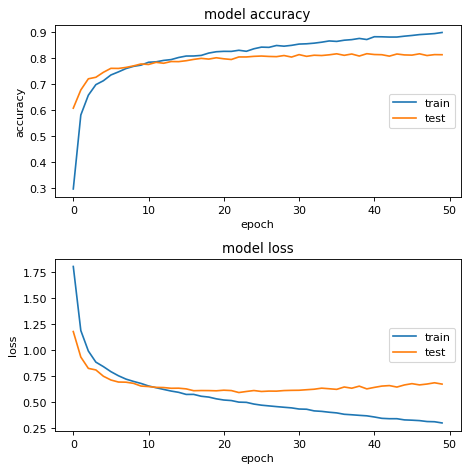

```python
plot_learning_curve(history)
```

```python
predictions_valid = model.predict(X_test.astype('float32'), batch_size=batch_size, verbose=2)
score_acc = accuracy_score(y_test, predictions_valid.round())
score_acc
```

```
0.790625
```

# Results Analysis of the CNN model

```python
import matplotlib.pyplot as plt
from numpy import argmax


df_results=pd.DataFrame()
df_results['file']=y_test_file
df_results['obs']=y_test_name
df_results['observed']=argmax(y_test, axis=1)
df_results['predicted']=argmax(model.predict(X_test.astype('float32'), batch_size=batch_size, verbose=2), axis=1)
```

```python
# obs= argmax(y_test, axis=1)
# pred = argmax(model.predict(X_test.astype('float32'), batch_size=batch_size, verbose=2), axis=1)
# plt.imshow(X_test_check[obs ==pred][1])
# y_test_file[obs ==pred][1]
# y_test_name[obs ==pred][1]
```

```python
indices = df_results.drop_duplicates(subset='obs', keep="first")[['obs', 'observed']].reset_index()
del indices['index']
indices.columns= ["pred", "id"]
indices
```

|  | pred | id |
| --- | --- | --- |
| 0 | blueberry | 6 |
| 1 | apple | 5 |
| 2 | strawberry | 1 |
| 3 | pear | 3 |
| 4 | blackberry | 4 |
| 5 | banana | 0 |
| 6 | peanut | 2 |
| 7 | grapes | 7 |

```python
df_results2 = df_results.merge(indices, left_on="predicted", right_on="id")[['file', 'obs', 'pred', 'observed','predicted']]
#random sample of results
np.random.seed(12345)
rows = np.random.choice(df_results2.index.values, 10)
sampled_df = df_results2.ix[rows]
sampled_df
```

|  | file | obs | pred | observed | predicted |
| --- | --- | --- | --- | --- | --- |
| 482 | 18ae0119-eeb9-417b-9943-7a8766995837.jpeg | strawberry | strawberry | 1 | 1 |
| 1509 | 27da0033-6d1f-471b-b0d4-b00bf9d63400.jpeg | grapes | blackberry | 7 | 4 |
| 1309 | c12756fe-81aa-4690-b5ef-3d22aa066d6a.jpeg | peanut | peanut | 2 | 2 |
| 129 | 4f698163-f7f9-497d-afa4-57036aaa48ad.jpeg | apple | blueberry | 5 | 6 |
| 1444 | 3c757692-cdb5-4fff-a5ed-4578f358853b.jpeg | blackberry | blackberry | 4 | 4 |
| 1449 | b69b3191-1032-4514-8655-2b7b43e37eb3.jpeg | blackberry | blackberry | 4 | 4 |
| 382 | 87f7a27d-1e03-4f09-8ea5-50508a62aa75.jpeg | apple | apple | 5 | 5 |
| 1381 | df1d69d4-d968-4d83-a255-e3d2c4c3315e.jpeg | peanut | peanut | 2 | 2 |
| 546 | 40b9163d-c1ff-47b5-8a19-40f08a278c1f.jpeg | strawberry | strawberry | 1 | 1 |
| 1565 | 7d1fe22c-2e15-4e37-82f6-933e090da427.jpeg | blackberry | blackberry | 4 | 4 |

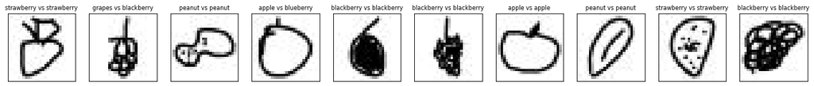

```
observed vs prediction
```

```python
import matplotlib.pyplot as plt
from sklearn.metrics import classification_report

X_test_check = X_test.reshape(X_test.shape[0], 28, 28)

n = 10 # how many digits we will display
plt.figure(figsize=(20, 4))
for i in range(n):
    # display original
    ax = plt.subplot(2, n, i + 1)
    plt.imshow(X_test_check[np.where(y_test_file == sampled_df['file'].values[i])[0]][0])
    obs= sampled_df['obs'].values[i]
    pred= sampled_df['pred'].values[i]
    plt.gray()
    ax.get_xaxis().set_visible(False)
    ax.get_yaxis().set_visible(False)

    plt.title(str(obs) + " vs " + str(pred), fontsize = 8 )
    plt.ylabel('loss')
    plt.xlabel('epoch')
plt.show()
print("observed vs prediction")
```

```python
predictions = argmax(model.predict(X_test.astype('float32'), batch_size=batch_size, verbose=2), axis=1)
print(classification_report(y_test.argmax(axis=1),
        predictions,
        target_names=[str(x) for x in indices.id]))
```

```
              precision    recall  f1-score   support

           6       0.95      0.90      0.92       200
           5       0.89      0.88      0.88       200
           1       0.86      0.84      0.85       200
           3       0.90      0.84      0.87       200
           4       0.72      0.61      0.66       200
           0       0.83      0.86      0.85       200
           2       0.73      0.66      0.69       200
           7       0.63      0.85      0.73       200

   micro avg       0.81      0.81      0.81      1600
   macro avg       0.81      0.81      0.81      1600
weighted avg       0.81      0.81      0.81      1600
```

## Checking the predictions

```python
from sklearn.metrics import confusion_matrix
import itertools

def plot_confusion_matrix(cm, classes,
                          normalize=False,
                          title='Confusion matrix',
                          cmap=plt.cm.Blues):
    """
    This function prints and plots the confusion matrix.
    Normalization can be applied by setting `normalize=True`.
    """
    if normalize:
        cm = cm.astype('float') / cm.sum(axis=1)[:, np.newaxis]
        print("Normalized confusion matrix")
    else:
        print('Confusion matrix, without normalization')

    print(cm)
    fig_size = plt.rcParams["figure.figsize"]
    fig_size[0] = 12
    fig_size[1] = 9
    plt.rcParams["figure.figsize"] = fig_size
    plt.imshow(cm, interpolation='nearest', cmap=cmap)
    plt.title(title)
    plt.colorbar()
    tick_marks = np.arange(len(classes))
    plt.xticks(tick_marks, classes, rotation=45)
    plt.yticks(tick_marks, classes)

    fmt = '.2f' if normalize else 'd'
    thresh = cm.max() / 2.
    for i, j in itertools.product(range(cm.shape[0]), range(cm.shape[1])):
        plt.text(j, i, format(cm[i, j], fmt),
                 horizontalalignment="center",
                 color="white" if cm[i, j] > thresh else "black")

    plt.ylabel('True label')
    plt.xlabel('Predicted label')
    plt.tight_layout()
```

```python
tmp=df_results2[df_results2.pred==df_results2.obs][['file','obs']].groupby(['obs']).agg(['count'])
tmp
```

| obs | file count |
| --- | --- |
| apple | 172 |
| banana | 180 |
| blackberry | 123 |
| blueberry | 132 |
| grapes | 171 |
| peanut | 169 |
| pear | 169 |
| strawberry | 175 |

```python
confusion_matrix(df_results2.obs, df_results2.pred)
```

```
array([[172,   0,   1,  12,   1,   0,   6,   8],
       [  0, 180,   1,   4,  10,   4,   1,   0],
       [  3,   1, 123,  10,  53,   7,   1,   2],
       [ 18,   1,  13, 132,  20,   7,   2,   7],
       [  0,   3,  17,   6, 171,   1,   2,   0],
       [  0,   2,   7,   9,   4, 169,   7,   2],
       [  8,   1,   2,   3,   6,   9, 169,   2],
       [  6,   2,   7,   5,   5,   0,   0, 175]])
```

```
Normalized confusion matrix
[[0.86  0.    0.005 0.06  0.005 0.    0.03  0.04 ]
 [0.    0.9   0.005 0.02  0.05  0.02  0.005 0.   ]
 [0.015 0.005 0.615 0.05  0.265 0.035 0.005 0.01 ]
 [0.09  0.005 0.065 0.66  0.1   0.035 0.01  0.035]
 [0.    0.015 0.085 0.03  0.855 0.005 0.01  0.   ]
 [0.    0.01  0.035 0.045 0.02  0.845 0.035 0.01 ]
 [0.04  0.005 0.01  0.015 0.03  0.045 0.845 0.01 ]
 [0.03  0.01  0.035 0.025 0.025 0.    0.    0.875]]
```

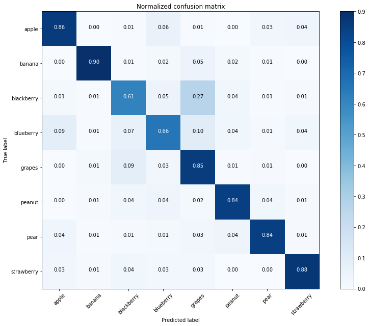

```python
plot_confusion_matrix(confusion_matrix(df_results2.obs, df_results2.pred) , classes=tmp.index.get_values(), normalize=True,
                      title='Normalized confusion matrix')
```

# Transfer Learning Approaches

https://www.kaggle.com/moltean/fruits

[figure not shown]

```python
import keras
import numpy as np
from keras.applications import vgg16, inception_v3, resnet50, mobilenet

#Load the VGG model
vgg_model = vgg16.VGG16(weights='imagenet')
```

[output not shown]

```python
print(vgg_model.summary())
```

```
_________________________________________________________________
Layer (type)                 Output Shape              Param #
=================================================================
input_1 (InputLayer)         (None, 224, 224, 3)       0
_________________________________________________________________
block1_conv1 (Conv2D)        (None, 224, 224, 64)      1792
_________________________________________________________________
block1_conv2 (Conv2D)        (None, 224, 224, 64)      36928
_________________________________________________________________
block1_pool (MaxPooling2D)   (None, 112, 112, 64)      0
_________________________________________________________________
block2_conv1 (Conv2D)        (None, 112, 112, 128)     73856
_________________________________________________________________
block2_conv2 (Conv2D)        (None, 112, 112, 128)     147584
_________________________________________________________________
block2_pool (MaxPooling2D)   (None, 56, 56, 128)       0
_________________________________________________________________
block3_conv1 (Conv2D)        (None, 56, 56, 256)       295168
_________________________________________________________________
block3_conv2 (Conv2D)        (None, 56, 56, 256)       590080
_________________________________________________________________
block3_conv3 (Conv2D)        (None, 56, 56, 256)       590080
_________________________________________________________________
block3_pool (MaxPooling2D)   (None, 28, 28, 256)       0
_________________________________________________________________
block4_conv1 (Conv2D)        (None, 28, 28, 512)       1180160
_________________________________________________________________
block4_conv2 (Conv2D)        (None, 28, 28, 512)       2359808
_________________________________________________________________
block4_conv3 (Conv2D)        (None, 28, 28, 512)       2359808
_________________________________________________________________
block4_pool (MaxPooling2D)   (None, 14, 14, 512)       0
_________________________________________________________________
block5_conv1 (Conv2D)        (None, 14, 14, 512)       2359808
_________________________________________________________________
block5_conv2 (Conv2D)        (None, 14, 14, 512)       2359808
_________________________________________________________________
block5_conv3 (Conv2D)        (None, 14, 14, 512)       2359808
_________________________________________________________________
block5_pool (MaxPooling2D)   (None, 7, 7, 512)         0
_________________________________________________________________
flatten (Flatten)            (None, 25088)             0
_________________________________________________________________
fc1 (Dense)                  (None, 4096)              102764544
_________________________________________________________________
fc2 (Dense)                  (None, 4096)              16781312
_________________________________________________________________
predictions (Dense)          (None, 1000)              4097000
=================================================================
Total params: 138,357,544
Trainable params: 138,357,544
Non-trainable params: 0
_________________________________________________________________
None
```

```python
plot_keras_model(vgg_model, show_shapes=True, show_layer_names=False)
```

[figure not shown]

# Doing Predictions using Transfer Learning

```python
from keras.preprocessing.image import load_img
from keras.preprocessing.image import img_to_array
from keras.applications.imagenet_utils import decode_predictions
import matplotlib.pyplot as plt
%matplotlib inline


def make_prediction(image, model):

    filename = image

    original = load_img(filename, target_size=(224, 224))
    numpy_image = img_to_array(original)
    image_batch = np.expand_dims(numpy_image, axis=0)
    processed_image = vgg16.preprocess_input(image_batch.copy())
    predictions = vgg_model.predict(processed_image)
    #print('PIL image size',original.size)
    label = decode_predictions(predictions)
    plt.imshow(original)
    plt.show()
    print(label)
```

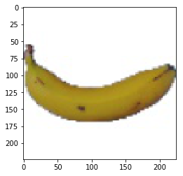

```
[[('n07753592', 'banana', 0.9997032), ('n03532672', 'hook', 5.0991028e-05), ('n03495258', 'harp', 5.059986e-05), ('n07749582', 'lemon', 4.763837e-05), ('n01945685', 'slug', 1.725897e-05)]]
```

```python
make_prediction('images/banana.jpg',vgg_model  )
```

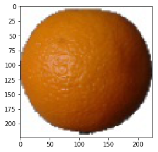

```
[[('n07747607', 'orange', 0.8934567), ('n07749582', 'lemon', 0.09272559), ('n03134739', 'croquet_ball', 0.006279422), ('n04409515', 'tennis_ball', 0.0043564364), ('n03942813', 'ping-pong_ball', 0.001051664)]]
```

```python
make_prediction('images/orange.jpg',vgg_model )
```

### Filters Visualization

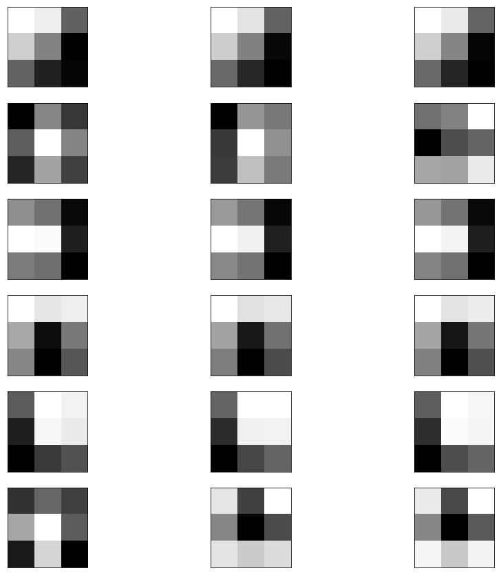

```python
from matplotlib import pyplot
# load the model
model = vgg_model
# retrieve weights from the second hidden layer
filters, biases = model.layers[1].get_weights()
# normalize filter values to 0-1 so we can visualize them
f_min, f_max = filters.min(), filters.max()
filters = (filters - f_min) / (f_max - f_min)
# plot first few filters
n_filters, ix = 6, 1
pyplot.rcParams["figure.figsize"] = (15,15)
for i in range(n_filters):
	# get the filter
	f = filters[:, :, :, i]
	# plot each channel separately
	for j in range(3):
		# specify subplot and turn of axis
		ax = pyplot.subplot(n_filters, 3, ix)
		ax.set_xticks([])
		ax.set_yticks([])
		# plot filter channel in grayscale
		pyplot.imshow(f[:, :, j], cmap='gray')
		ix += 1
# show the figure
pyplot.show()
```

# Plotting Feature Maps

```python
from keras.models import Model
from numpy import expand_dims
from keras.applications.vgg16 import preprocess_input

# redefine model to output right after the first hidden layer
model2 = Model(inputs=model.inputs, outputs=model.layers[1].output)
model2.summary()
```

```
_________________________________________________________________
Layer (type)                 Output Shape              Param #
=================================================================
input_1 (InputLayer)         (None, 224, 224, 3)       0
_________________________________________________________________
block1_conv1 (Conv2D)        (None, 224, 224, 64)      1792
=================================================================
Total params: 1,792
Trainable params: 1,792
Non-trainable params: 0
_________________________________________________________________
```

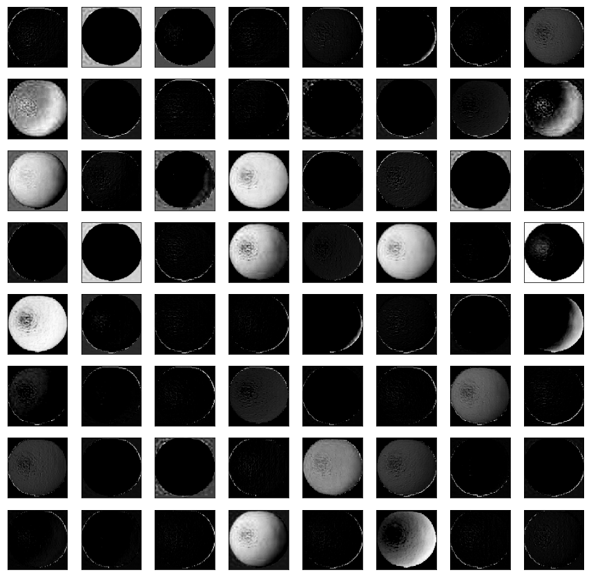

```python
# load the image with the required shape
img = load_img('images/orange.jpg', target_size=(224, 224))
# convert the image to an array
img = img_to_array(img)
# expand dimensions so that it represents a single 'sample'
img = expand_dims(img, axis=0)
# prepare the image (e.g. scale pixel values for the vgg)
img = preprocess_input(img)
# get feature map for first hidden layer
feature_maps = model2.predict(img)
# plot all 64 maps in an 8x8 squares
square = 8
ix = 1

pyplot.rcParams["figure.figsize"] = (15,15)
for _ in range(square):
	for _ in range(square):
		# specify subplot and turn of axis
		ax = pyplot.subplot(square, square, ix)
		ax.set_xticks([])
		ax.set_yticks([])
		# plot filter channel in grayscale
		pyplot.imshow(feature_maps[0, :, :, ix-1], cmap='gray')
		ix += 1

# show the figure
pyplot.show()
```